# SwiftKey Corpus Milestone Report

# SwiftKey Corpus: Exploratory Milestone Report

*Data Science Capstone milestone · 2026-10-07*

## Executive summary

The three official English SwiftKey files were downloaded and scanned in full. Together they contain **4,269,678 lines** and approximately **101.22 million cleaned word tokens**. Blogs have the most tokens, while Twitter has the most and shortest lines. A deterministic 1% sample supports exploratory plots and a separate 0.8%/0.2% split supports model development and validation. The final product uses a compact 1–4 gram backoff model.

## Corpus inventory

| Source | Bytes | Lines | Cleaned tokens |
| --- | --- | --- | --- |
| Blogs | 210,160,014 | 899,288 | 37,509,522 |
| News | 205,811,889 | 1,010,242 | 34,042,817 |
| Twitter | 167,105,338 | 2,360,148 | 29,663,285 |

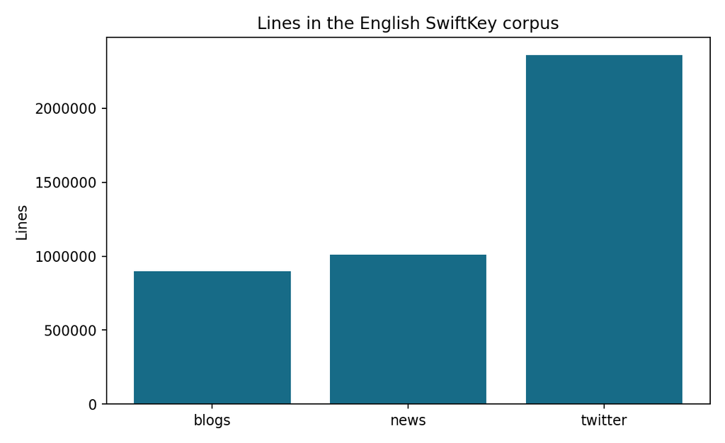

Line counts

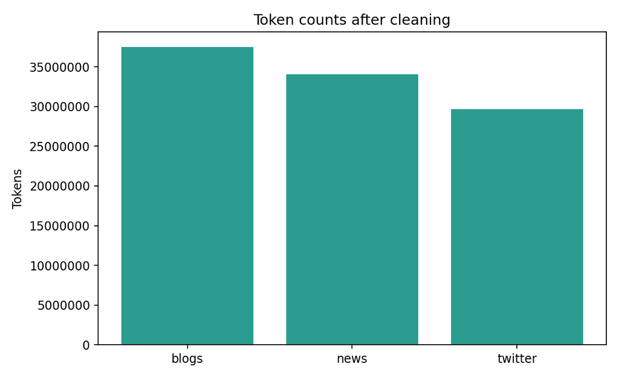

Token counts

## Line-length patterns

URLs and @mentions are removed; text is lowercased; tokens contain letters and internal apostrophes. A small explicit profanity blocklist prevents common offensive terms from entering predictions.

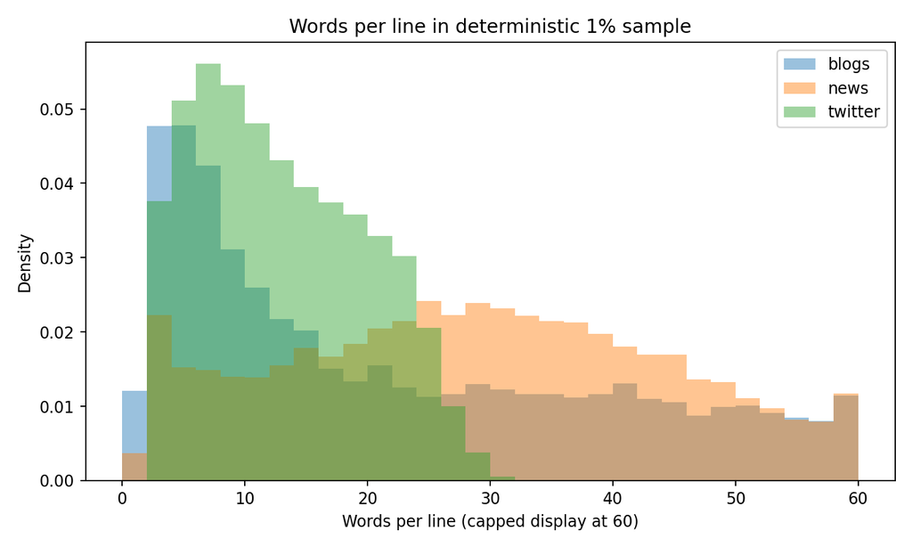

Words per line

## Modeling plan and validation

The model counts unigrams through four-grams. It first searches the last three words, then backs off to two words, one word, and global frequency. Tables keep five candidates per context for a small and responsive deployment.

On **193,477 held-out tokens**, top-1 accuracy is **12.44%** and top-3 accuracy is **20.07%**. Improvements could use more training data, interpolated probabilities, broader profanity filtering, and validation-tuned pruning.

## Product plan

The Shiny app accepts a phrase, applies the same tokenizer, and returns one predicted next word plus optional alternatives and the n-gram order used.